# Durable Empowerment: Designing Index Insurance to Maximize Benefits for Women

Andrew Hobbs, Digital Credit and Women’s Economic Empowerment Convening

6/27/2019

# Background

Randomized Controlled Trial in Samburu County, Kenya

- BOMA Rural Entrepreneur Access Program
  - Poverty Graduation for Women
  - Targets poorest in communities
  - Cash grant ($200 + $100)
  - Savings group (3-5 women)
  - Health insurance for two years
  - Mentor + business training
- Index-Based Livestock Insurance (IBLI)
  - Uses satellites to monitor drought conditions
  - Sends (mobile) money when droughts strike.

# Samburu County

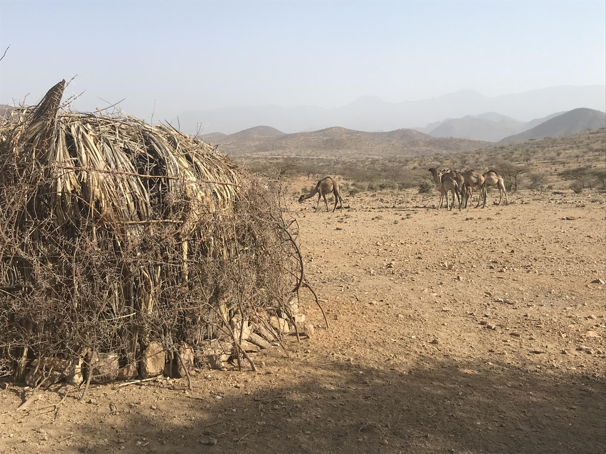

- Majority nomadic pastoralists.
- Women stay at base camp with children and few livestock.
- Men travel to satellite camps with herd in search of pasture.

# Fragile Empowerment: BRAC

Many long-term benefits, but increases in empowerment fall away.

“It is striking that there is no evidence of mean reversion in per capita consumption, food security, or assets. The gains in financial inclusion, total time spent working, income and revenue, and mental health have declined but are still positive and statistically significant. **The gains in physical health and women’s empowerment have declined and are no longer statistically significant.**”

Source: Banerjee et al. (2015), “A multifaceted program causes lasting progress for the very poor” *Science.*

# Fragile Empowerment: BOMA REAP

Poverty reduction was durable, but womens’ gains in assets less so.

| Measure | Endline | Follow.Up |
| --- | --- | --- |
| Household Livestock** | 8.2 | 12.4 |
| Women-owned Livestock*** | 7.2 | 3.7 |
| Savings Groups Active | 95% | 73% |

Explanation: repeated droughts led to business liquidation and sales of womens’ livestock.

# Why is Empowerment Fragile?

With great empowerment comes great financial responsibility:

“[Before] when a child needs [a] uniform and [my] husband is at satellite camp, I have to send [a] message to him and wait for him to send money and the child will not go to school until we get the money for the uniform. And now, I just make the decision even **if the husband is far away and there’s a need to buy the uniform, I just give child the money.**”

“…It’s us who does business, it’s us who makes decisions of what to be done, **it’s us who buy[s] food for children.** We don’t have even that time nowadays of husbands telling us to buy food now,…”

Source: BOMA Qualitative Assessment, February 2018

# Why is Empowerment Fragile?

Women take over household expenses:

“…They buy goat[s] and sell [them] and they buy food […]. **They just sell their business and livestock and send food for me also** […]…”

“…Since my wife [has been] doing BOMA, I have never sold a goat […]. I say thank you very much because that money has helped me to pay fees and **I have never sold any livestock to pay fees since my wife came to BOMA**,…”

Source: BOMA Qualitative Assessment, February 2018

# Separate Spheres and Livestock Insurance

How involved are you in decisions regarding… ?

[figure not shown]

so how does **livestock insurance** benefit women?

# Her Problem

Wife allocates her income plus a transfer $t$ from the husband between consumption $c_w$, household public goods $z$, and investment $k_w$.

$$v_w(y_w,y_m)=\max_{c_w, z, k_w} u_w(c_w, z) + \beta_wE[v(y_w',y_m')],$$
production $f(k_w)$ experiences shock $\epsilon$
$$y_w' = f(k_w)\epsilon_w$$
and
$$c_w+z+k_w\leq y_w + t(y_m, y_w)$$

# His Problem

Husband allocates his budget between a transfer to the wife, his own consumption, and investment.

$$v_m(y_m, y_w)=\max_{c_m, t, k_m} u_m(c_m, z(t, y_w)) + \beta_wE[v(y_m', y_w')]$$
where
$$y_m' = f(k_m)\epsilon_m$$
and
$$c_m+t+k_m\leq y_m$$

# Model Result: Womens’ investments at greater risk than mens’ during droughts

When droughts strike:

- If women have little capital/income, men maintain transfers ensure public goods production (school fees, medical bills, food).
- If women have their own income, men reduce transfers.
- Women know this, which reduces their returns to investment (esp. if man is not poor) - may be better to spend a grant today on consumption, food, and education.

# Whose sphere does insurance belong to?

Insurance is a new asset type - whose income does it enter?

Index Based **Livestock** Insurance seems to fit in the male sphere.

What about **family** drought insurance?

# SimPastoralist

We designed a tablet-based game to study insurance demand and investment under different framings.

[video not shown]

# SimPastoralist Couples

In the couples version, risk and expenses can be pooled.

[video not shown]

# SimPastoralist: Reception

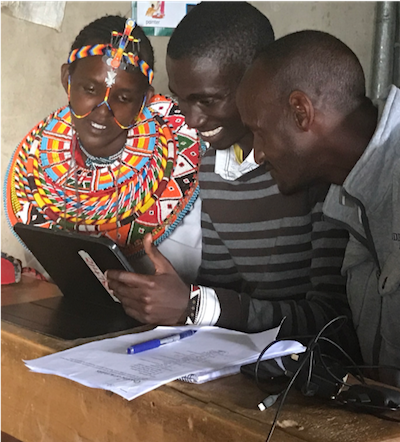

- Can we play longer?
- This is very educational.
- Why can’t I buy chickens?

# Experiment: Overview

387 couples, picked randomly from respondents in a subset of regions from our baseline survey.

Conducted by 4 teams who worked with groups of ~8 couples at a time across Samburu County.

Compensation: 300 KSh for attending plus incentive based on performance.

# Experiment: Framing

**Livestock**:

- Droughts threaten livestock.
- Insurance can help protect livestock.

**Family**:

- Droughts threaten livestock and also make it hard to pay for household needs.
- Insurance can help protect livestock and can also be used to pay household expenses, school fees, and more.

# Experiment: Randomization

At the session level, we randomize framing and starting budgets.

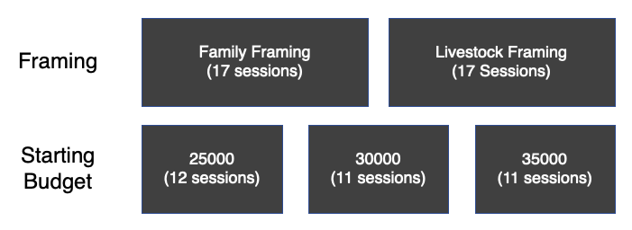

# Experiment: Individual Sessions

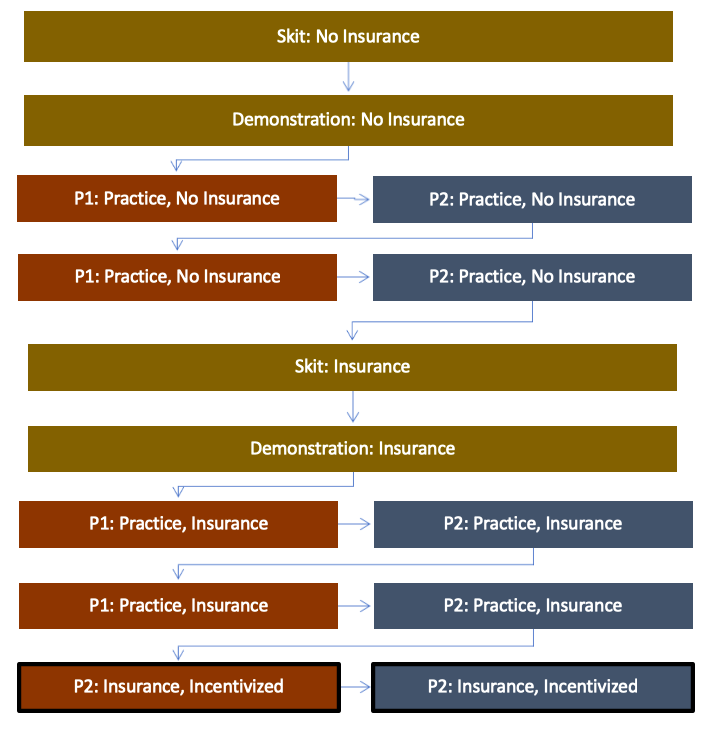

# Experiment: Couples Sessions

Game is identical, but with half the start budget and the ability to transfer funds.

- Two Practice Rounds
- One Incentivized Session

# Women insure more under family framing, men insure less

[figure not shown]

3SLS estimates controlling for wealth (endogenous) and time period, with history of shocks and starting budgets as instruments for wealth. SEs clustered at session level.

# Women invest more under family framing, men invest less

[figure not shown]

3SLS estimates controlling for wealth (endogenous) and time period, with history of shocks and starting budgets as instruments for wealth. SEs clustered at session level.

# Implications

- Naming and framing of financial products matters, especially when novel.
- Carefully designed asset protection for durable empowerment.

# Bringing Family Insurance to the Real World

- In reality, we can have both household and family insurance.
- Concept: allocate livestock units according to TLUs, family insurance based on assessment of household costs during drought (school fees, food, etc)
- Use promotional videos to standardize (part of) marketing, run experiment within existing RCT.